# Praca domowa 2

Jan Taran

## Dane

Dane wykorzystane w Pracy domowej 2 opisują wycenę nieruchmości. Każda obserwacja jest pewną nieruchmością, która posiada informacje takie jak powierzchnia, liczba pokoi, liczba łazienek i wiele więcj. Opis wszystkich kolumn w pliku `README.md`.

## Zadanie 1

Jak wygląda rozkład ceny nieruchomości w poszczególnych kodach pocztowych na przestrzeni lat? Rozważamy kody pocztowe, które mają więcej niż 280 posiadłości.

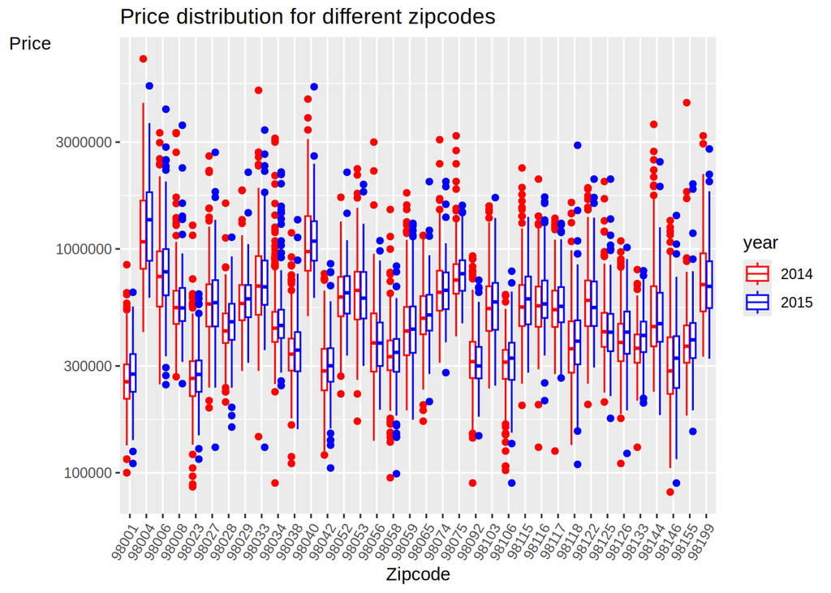

```r
options(scipen = 12)

df %>%
  group_by(zipcode) %>%
  mutate(ilosc = n()) %>%
  filter(ilosc > 280) %>%
  mutate(year = substr(date, 1, 4)) %>%
  ggplot(aes(x=as.factor(zipcode), y=price, color = year))+
  geom_boxplot()+
  scale_y_log10()+
  scale_color_manual(values = c("red", "blue"))+
  labs(title = "Price distribution for different zipcodes",
        x="Zipcode", y="Price" )+
  theme(axis.text.x = element_text(angle = 60, hjust=1),
        axis.title.y = element_text(angle = 0) )
```

Można wyróżnić lokalizacje, gdzie ceny są wyraźnie wyższe niż dla innych kodów pocztowych, lub też gdzie są wyraźnie niższe, ale większość jest mniej więcej w tym samym przedziale. Widać również lekki wzrost ceny w 2015 roku

## Zadanie 2

Czy jest różnica w rozkładzie ceny nierchomości od powierzchni mieszkalnej uwzględniając podział na nieruchomości z piwnicą i bez?

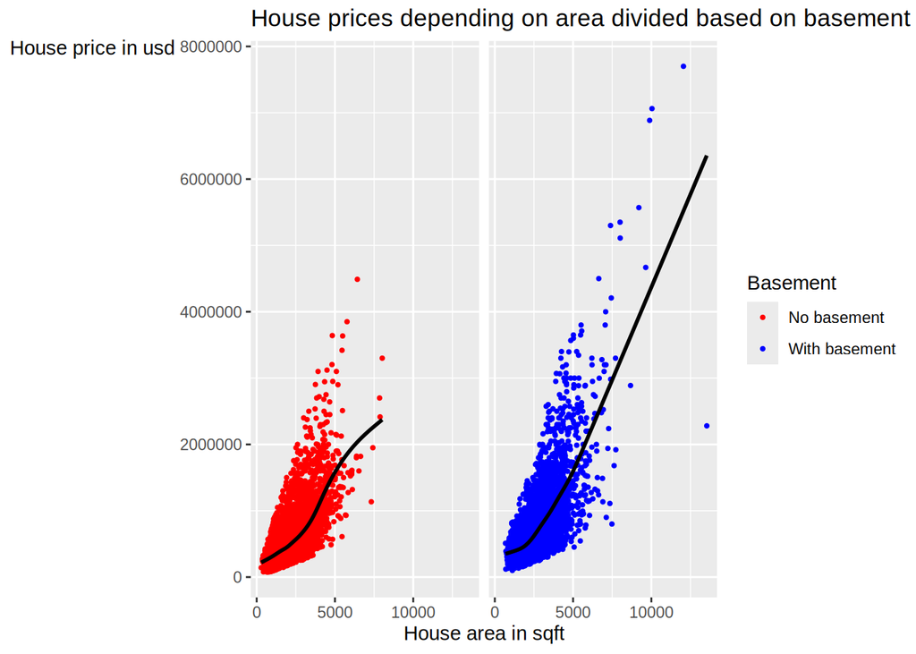

```r
options(scipen = 12)

df %>%
  mutate(basement = if_else(sqft_basement > 0, 1, 0)) %>%
  ggplot(aes(x = sqft_living, y = price, color = as.factor(basement))) +
  facet_grid(~basement, labeller = labeller(NULL)) +
  geom_point(size = 0.75) +
  geom_smooth(method = "gam", se = FALSE, color = "black") +
  scale_color_manual(
    values = c("0" = "red", "1" = "blue"),
    labels = c("0" = "No basement", "1" = "With basement")) +
  labs(title = "House prices depending on area divided based on basement",
       x = "House area in sqft",
       y = "House price in usd",
       color = "Basement")+
  theme(axis.title.y = element_text(angle = 0),
        strip.text.x = element_blank())
```

```r
#więcej informacji z dodatkową biblioteką
#install.packages("ggExtra")
#library(ggExtra)
#p1 <- df %>% filter(sqft_basement > 0) %>%
#  ggplot(aes(x = sqft_living, y = price)) +
#  geom_point(size = 0.75, color = "blue") +
#  geom_smooth(method = "gam", se = FALSE, color = "black") +
#  labs(title = "With Basement")
#p2 <- df %>% filter(sqft_basement == 0) %>%
#  ggplot(aes(x = sqft_living, y = price)) +
#  geom_point(size = 0.75, color = "red") +
#  geom_smooth(method = "gam", se = FALSE, color = "black") +
#  labs(title = "Without Basement")
#ggMarginal(p1, type = "histogram")
#ggMarginal(p2, type = "histogram")
```

Wyraźnie widać, że domy z piwnicą mają potencjał na znacznie wyższą cenę, skupienie jednak jest podobne dla obu asymptoty również są podobne dla obu

## Zadanie 3

Jaka jest zależność pomiędzy jakością wykończenia nieruchomości a liczbą pięter?

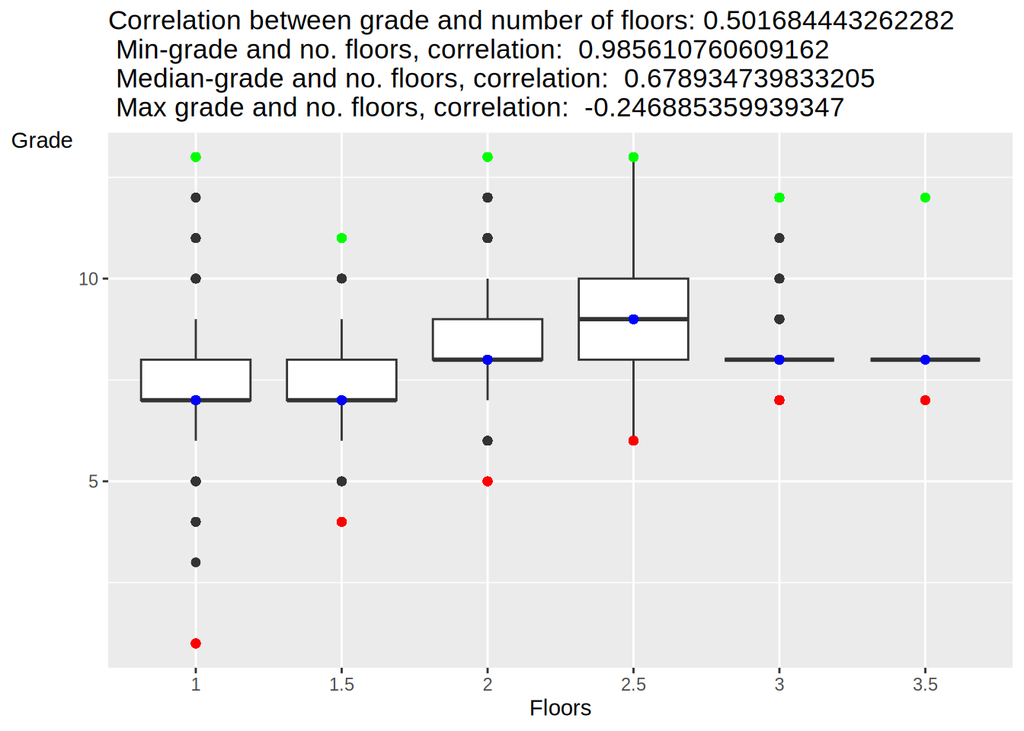

```r
options(scipen = 12)


pom<-df %>%
      group_by(floors) %>%
      summarise(max_grade = max(grade), median_grade = median(grade),
                min_grade = min(grade))
cor_min_grade <- cor(pom$floors, pom$min_grade, method = "spearman")
cor_median_grade <- cor(pom$floors, pom$median_grade, method = "spearman")
cor_max_grade <- cor(pom$floors, pom$max_grade, method = "spearman")

#liczę teraz korelacje,
#ponieważ później dane potrzebne do ich wyliczenia będą zduplikowane
# i wyszedłby z tego szmieszny_blad

pom <- df %>%
      group_by(floors) %>%
      reframe(max_grade = max(grade), median_grade = median(grade),
              min_grade = min(grade), grade = grade)
#smieszny_blad <- cor(pom$floors, pom$min_grade, method = "spearman")
#print(smieszny_blad, digits = 22)
#0.999 999 450 3467112272332

pom %>%
  ggplot(aes(x=as.factor(floors), y=as.numeric(grade)))+
  geom_boxplot()+
  geom_point(aes(y=as.numeric(min_grade),color = "Min-grade"), color = "red")+
  geom_point(aes(y=as.numeric(median_grade), col = "Median-grade"), color="blue")+
  geom_point(aes(y=as.numeric(max_grade), col = "Max-grade"), color="green")+
  ylim(c(min(df$grade), max(df$grade)))+ #dla ładnego wyświetlania
  labs(title = paste("Correlation between grade and number of floors:",
                     cor(pom$floors, pom$grade, method = "spearman"),"\n",
                     "Min-grade and no. floors, correlation: ",
                     cor_min_grade,"\n",
                     "Median-grade and no. floors, correlation: ",
                     cor_median_grade,"\n",
                     "Max grade and no. floors, correlation: ",
                     cor_max_grade),
       x = "Floors",
       y = "Grade")+
  theme(axis.title.y = element_text(angle = 0))
```

Sprawdzam rozkład jakości wykonania dla każdej ilości pięter. Widać pewną zależność między ilością pięter a minimalną jakością wykonania, zaś maksymalna jakość wykonania jest mniej więcej taka sama dla każdej ilości pięter

## Zadanie 4

Jaka jest zależność między powierzchnią mieszkalną nieruchomości a powierzchnią gruntu w podziale na liczbę sypialni?

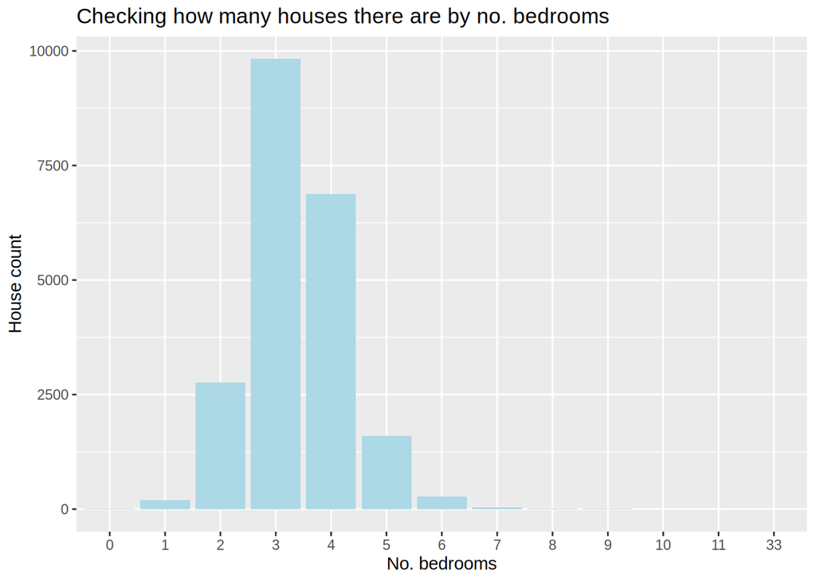

```r
options(scipen = 12)

#sprawdzam rozkład domów ze względu na ilość sypialni
df %>%
  ggplot(aes(x=as.factor(bedrooms))) +
  geom_bar(fill = "lightblue")+
  labs(
  title = "Checking how many houses there are by no. bedrooms",
    x = "No. bedrooms",
    y = "House count")
```

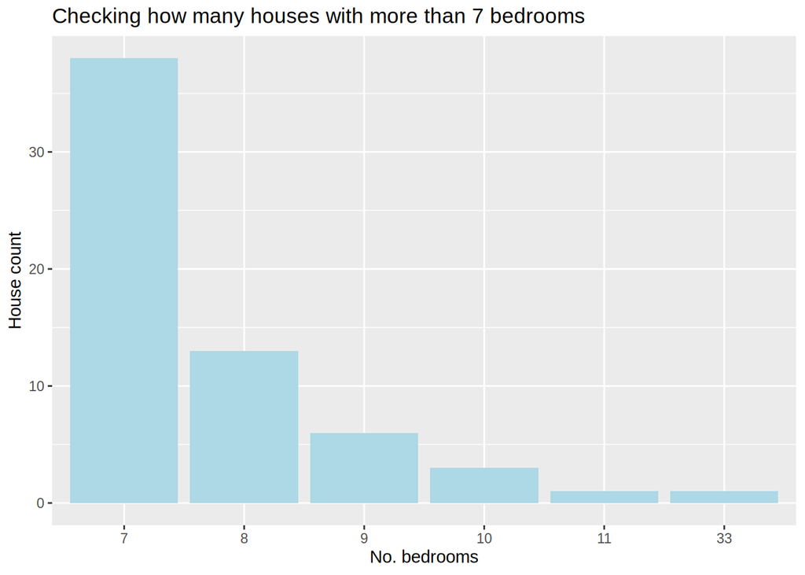

```r
df %>% filter(bedrooms>6) %>%
  ggplot(aes(x=as.factor(bedrooms))) +
  geom_bar(fill = "lightblue")+
  labs(
  title = "Checking how many houses with more than 7 bedrooms",
    x = "No. bedrooms",
    y = "House count")
```

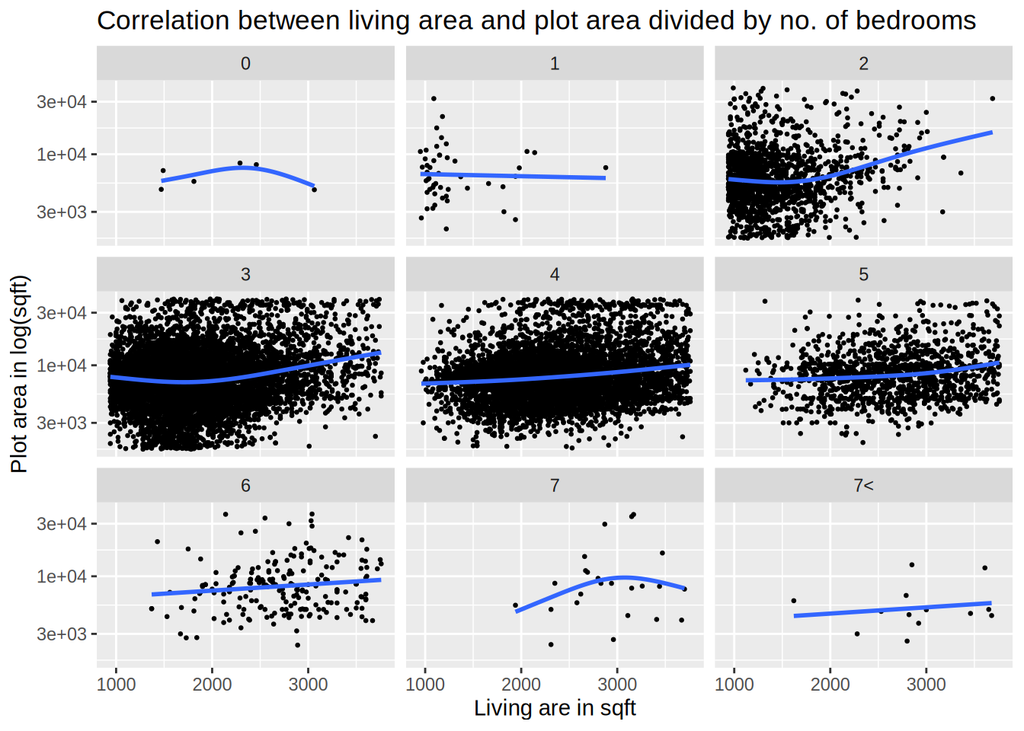

```r
#z tego wynika, że mało jest domów z 7< sypialniami, będę je traktował tak samo

options(scipen = -1)

df %>%  mutate(bedrooms = if_else(bedrooms>7, "7<", as.character(bedrooms))) %>%
  filter(between(sqft_living, quantile(sqft_living, probs = 0.05),
                 quantile(sqft_living, probs = 0.95))) %>%
  filter(between(sqft_lot, quantile(sqft_lot, probs = 0.05),
                 quantile(sqft_lot, probs = 0.95))) %>%
  ggplot(aes(x=sqft_living, y=sqft_lot))+
  facet_wrap(~bedrooms)+
  geom_point(size=0.5)+
  scale_y_log10()+
  geom_smooth(method = "gam", formula = y ~ s(x, k=5), se = FALSE)+
  labs(
title = "Correlation between living area and plot area divided by no. of bedrooms",
    x = "Living are in sqft",
    y = "Plot area in log(sqft)")
```

Odrzucam outliers’ów, którzy zaburzali widok Używam skali logarytmicznej, aby również bardziej były widoczne różnice Dodałem linie trendu, aby było bardziej widać w jakim kierunku to zmierza o tym wszystkim można się domyślać, że im więcej sypialni, tym większy dom, tym większy stosunek powierzchni mieszkalnej do powierzchni działki, ale mimo wszystko to jest niewielki wzrost

## Zadanie 5

Rozważmy tylko nieruchomości, które miały remont. W której dekadzie było najwięcej przeprowadzonych remontów? Czy w poszczególnych dekadach jest porównywalny procent nieruchmości dla każdej wartości miary jakości i wykończenia nieruchomości?

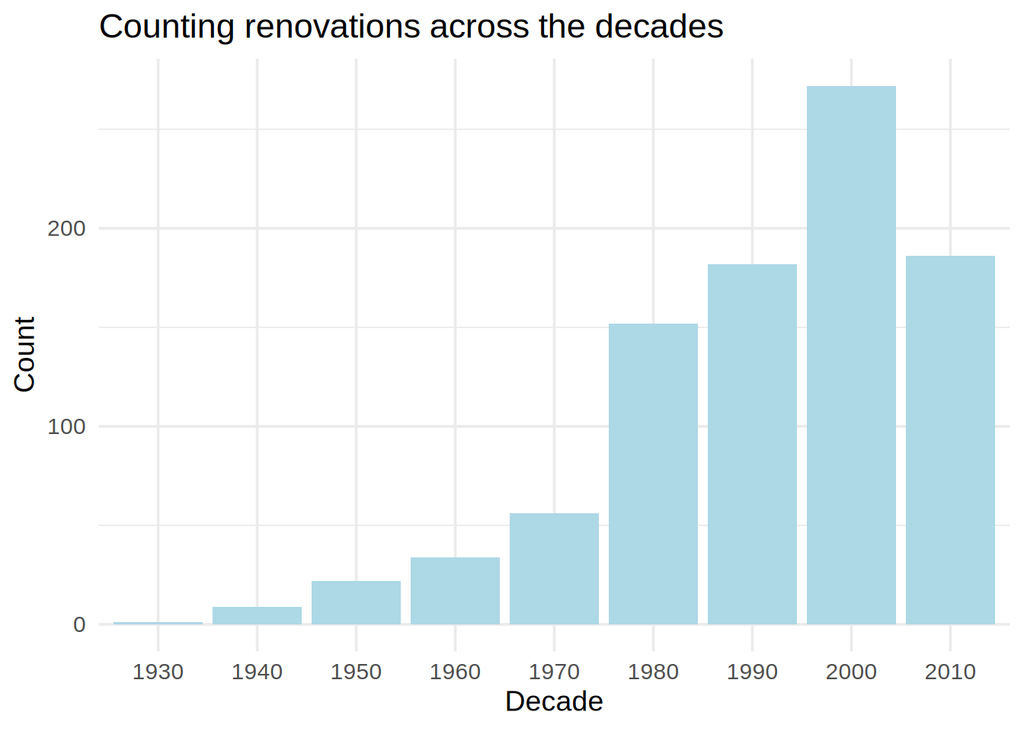

```r
options(scipen = 12)


Decades <- as.data.frame(seq((min(df[df$yr_renovated>0, 'yr_renovated'])%/% 10)*10,
                (max(df[df$yr_renovated>0, 'yr_renovated'])%/% 10)*10,
                by=10))
colnames(Decades) <- "decades"
#robię ramkę danych z dekadami, aby uniknąć sytuacji, gdzie pominę tą dekadę,
#gdzie nie było żadnych remontów

df %>%
  filter(yr_renovated>0) %>%
  mutate(decade = (yr_renovated %/% 10)*10) %>%
  left_join(Decades, join_by(decade == decades)) %>%
#w przypadku w którym w jednej dekadzie nie było żadnych
  #remontów to wcześniej nie byłoby wychwycone
  ggplot(aes(x=as.factor(decade))) +
  geom_bar(fill = "lightblue")+
  labs(
    title = "Counting renovations across the decades",
    x = "Decade",
    y = "Count") +
  theme_minimal(base_size = 14)
```

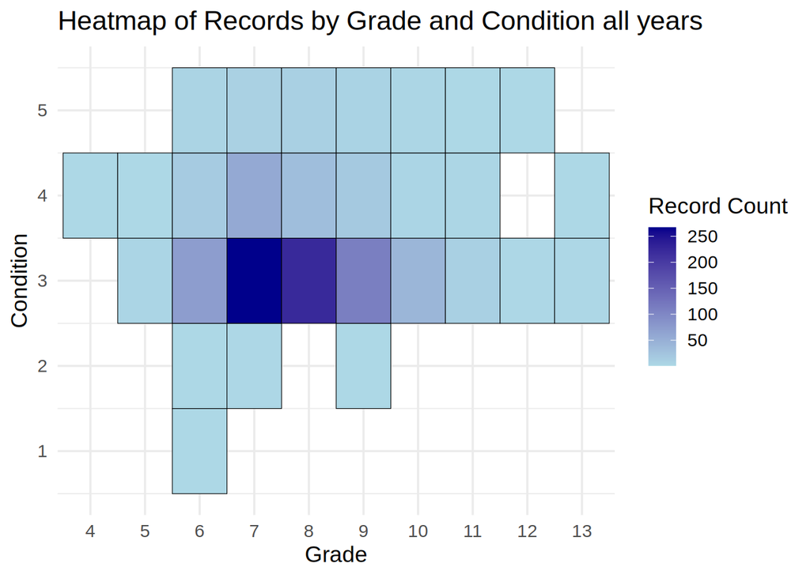

```r
#najwięcej remontów było w dekadzie 2000-2009

df %>%
  filter(yr_renovated>0) %>%
  count(grade, condition) %>%
  ggplot(aes(x = as.factor(grade), y = condition, fill = n))+
  geom_tile(color = "black", linewidth = 0.2) +
  scale_fill_gradient(low = "lightblue", high = "darkblue") +
  labs(
    title = "Heatmap of Records by Grade and Condition all years",
    x = "Grade",
    y = "Condition",
    fill = "Record Count"
  ) +
  theme_minimal(base_size = 14)
```

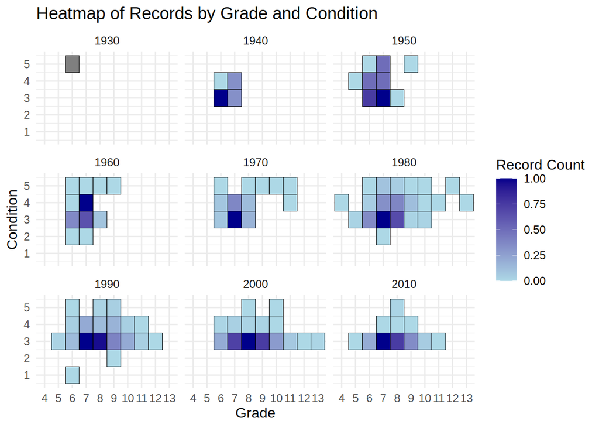

```r
df %>%
  filter(yr_renovated > 0) %>%
  mutate(decade = (yr_renovated %/% 10) * 10) %>%
  left_join(Decades, join_by(decade == decades)) %>%
  group_by(decade) %>%
  reframe(grade, condition, decade_count=n()) %>%
  count(grade, condition, decade, decade_count) %>%
  group_by(decade) %>%
  mutate(relative_color = (n / decade_count - min(n / decade_count)) /
                        (max(n / decade_count) - min(n / decade_count))) %>%
  ggplot(aes(x = as.factor(grade), y = condition, fill = relative_color)) +
  facet_wrap(~decade)+
  geom_tile(color = "black", linewidth = 0.2) +
  scale_fill_gradient(low = "lightblue", high = "darkblue") +
  labs(
    title = "Heatmap of Records by Grade and Condition",
    x = "Grade",
    y = "Condition",
    fill = "Record Count"
  )+
  theme_minimal(base_size = 12)
```

Najwięcej remontów było w dekadzie 2000-2009

## Zadanie 6

Jak prezentuje się wartość minimalna, średnia i maksymalna ceny nieruchmości w podziele na rok budowy nieruchomości.

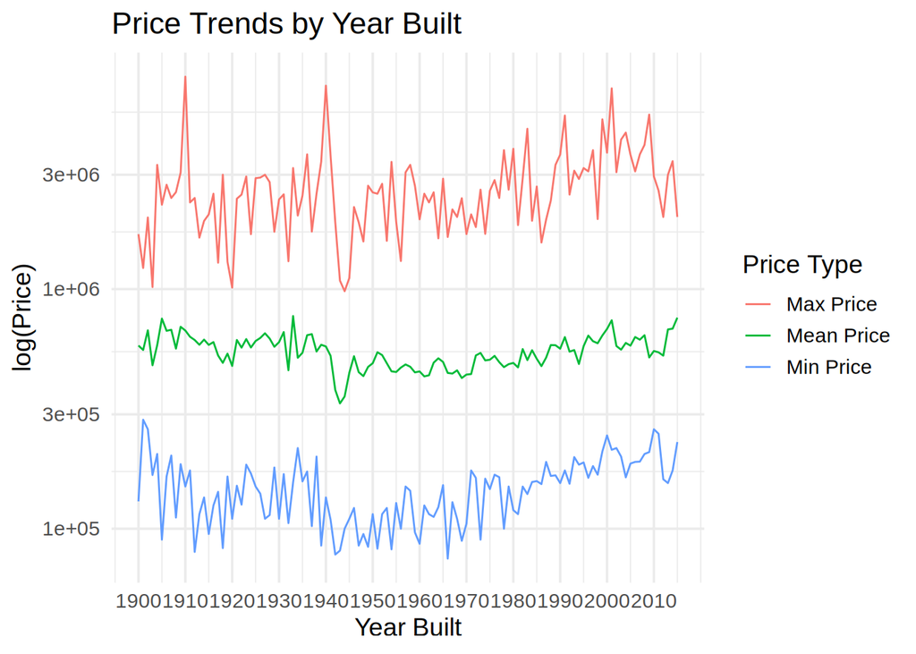

```r
options(scipen = -1)

df %>%
  group_by(yr_built) %>%
  summarise(min_price = min(price), mean_price = mean(price), max_price = max(price)) %>%
  ggplot(aes(x = yr_built)) +
  geom_line(aes(y = min_price, color = "Min Price")) +
  geom_line(aes(y = mean_price, color = "Mean Price")) +
  geom_line(aes(y = max_price, color = "Max Price")) +
  scale_y_log10()+
  scale_x_continuous(breaks=seq(min(df$yr_built), max(df$yr_built), 10))+
  labs(
    title = "Price Trends by Year Built",
    x = "Year Built",
    y = "log(Price)",
    color = "Price Type"
  ) +
  theme_minimal(base_size = 14)
```